# Cost-asymmetry analysis

### Ideal saccade gain under an asymmetric-quadratic loss

The asymmetric loss function is defined as
$$L(x)=\left[ a +(1-2a)\cdot 1_{x<0} \right] \cdot x^2$$
where $a$ is the asymmetry parameter, and $x$ is the landing error measured in “gain units”, i.e. in proportion of target distance (more precisely, if $E$ is the eccentricity of the target, and $S$ the saccade amplitude, then $x=\frac{S}{E}-1$). The aimpoint $\mu$ is defined as difference from a unit gain of 1, and $1_{x<0}$ is an indicator function that is equal to 1 when the argument in the subscript ($x<0$) is verified, and zero otherwise.

The expected loss is calculated by integrating the cost of each motor oucome weighted by its probability, and can be calculated as
$$\begin{align}
\mathbb{E}(L \mid \mu ,\sigma)=& \int_{-\infty}^{\infty} L(x) \cdot \phi \left(\frac{x-\mu}{\sigma}\right) \, dx \\
=&\left( 1-a\right)\left( \frac{{{\mu}^{2}}+{{\sigma}^{2}}}{2}+\frac{\frac{\sqrt{\pi}}{\sqrt{2}}\cdot \mathrm{erf}\left( \frac{-\mu}{\sqrt{2} \sigma}\right) \cdot \left( {{\mu}^{2}}+{{\sigma}^{2}}\right) -\mu\cdot \sigma\cdot {{e}^{-\frac{{{\mu}^{2}}}{2 {{\sigma}^{2}}}}}}{\sqrt{2\pi}}\right) \\
&+a \left( \frac{{{\mu}^{2}}+{{\sigma}^{2}}}{2}-\frac{\frac{\sqrt{\pi}}{\sqrt{2}}\cdot \mathrm{erf}\left( \frac{-\mu}{\sqrt{2} \sigma}\right) \cdot \left( {{\mu}^{2}}+{{\sigma}^{2}}\right) -\mu\cdot \sigma \cdot {{e}^{-\frac{{{\mu}^{2}}}{2 {{\sigma}^{2}}}}}}{\sqrt{2\pi}}\right) \\
=& \frac{\mu^2+\sigma^2}{2} + (1-2a) \frac{(\mu^2 + \sigma^2) \mathrm{erf}\left( \frac{-\mu}{\sqrt{2} \sigma} \right)}{2} + (2a-1) \frac{\mu \sigma e^{-\frac{\mu^2}{2 \sigma^2}}}{\sqrt{2\pi}}\\
=& \frac{\mu^2+\sigma^2}{2} + (1-2a) \left[ \frac{(\mu^2 + \sigma^2) \mathrm{erf}\left( \frac{-\mu}{\sqrt{2} \sigma} \right)}{2} - \frac{\mu \sigma e^{-\frac{\mu^2}{2 \sigma^2}}}{\sqrt{2\pi}} \right]
\end{align}$$
where we have assumed that the variability of motor outcomes is well described by a Gaussian distribution $x \sim \mathcal{N}(\mu,\sigma^2)$ ($\phi$ indicates the Gaussian probability density function). It is easy to verify that when $a=0.5$ (meaning that the cost function is symmetric) the last two terms of the function cancel out. In this case the minimum of the expected cost is obtained for $\mu=0$, as it should be, and depends on the variability (it is precisely $\frac{\sigma^2}{2}$).

Given a certain variability $\sigma$ of the motor outcomes, and a given cost asymmetry $a$, there is only one ideal aimpoint $\mu$ which minimizes the expected cost. The function is convex and it is straightforward to use one dimensional numerical optimization method (e.g. Brent method) to quickly find the minimum.

Here is a plot of the predicted and observed gain for each condition.

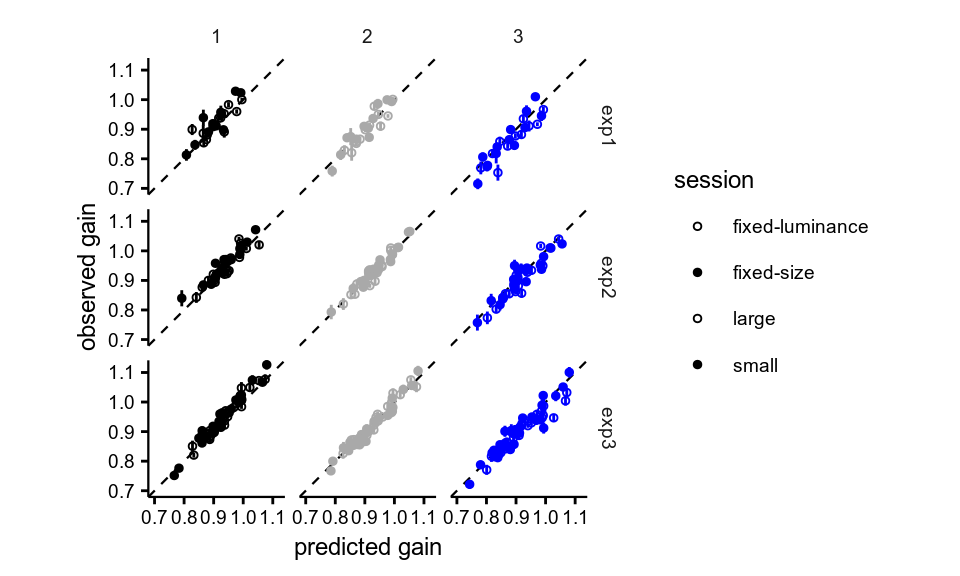

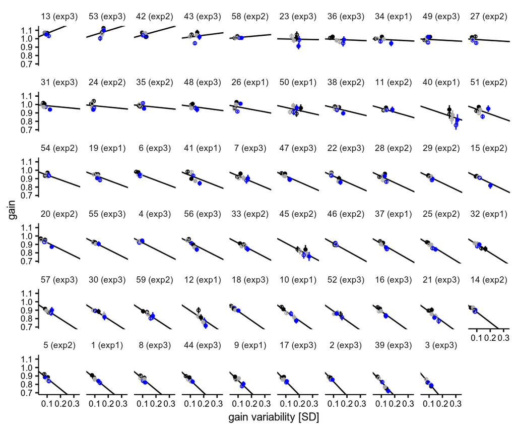

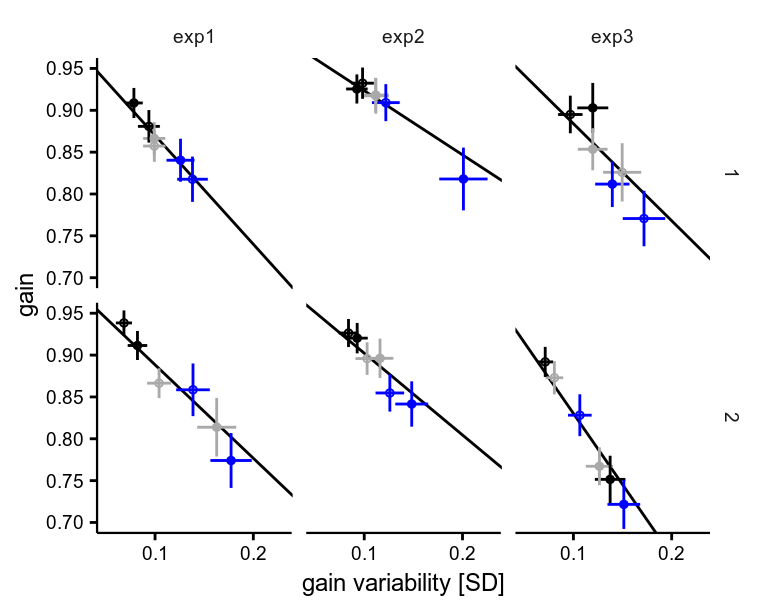

```r
dfit$CR <- dfit$alpha/(1-dfit$alpha)
dfit$LOCR <- log(dfit$alpha/(1-dfit$alpha))

dfit_ag <-aggregate(cbind(alpha, LOCR, CR)~ id + exp, dfit, mean)
summary(aov(LOCR ~ exp, dfit_ag)) # anova on the log-transformed cost , so that residuals are normal
```

```
##             Df Sum Sq Mean Sq F value Pr(>F)
## exp          2   2.94   1.470   0.671  0.515
## Residuals   56 122.68   2.191
```

```r
round(with(dfit_ag, tapply(alpha, exp, median)),digits=2)
```

```
## exp1 exp2 exp3
## 0.87 0.87 0.88
```

```r
with(dfit_ag, tapply(alpha, exp, FUN=bootFooCI, median, nsim=5000))
```

```
## $exp1
## 2.909592% 97.88213%
## 0.7524535 0.9434550
##
## $exp2
##  3.32861% 98.19438%
## 0.7410736 0.8952861
##
## $exp3
## 2.759475% 97.75385%
## 0.8194839 0.9483907
```

```r
round(with(dfit_ag, tapply(CR, exp, median)),digits=2)
```

```
## exp1 exp2 exp3
## 7.52 6.72 7.68
```

```r
with(dfit_ag, tapply(CR, exp, FUN=bootFooCI, median,nsim=5000))
```

```
## $exp1
## 1.498811% 96.21831%
##  2.815652 16.747652
##
## $exp2
##  2.01048% 96.96927%
##  2.879790  8.425292
##
## $exp3
## 1.969106% 96.92931%
##  4.539671 17.444982
```

### Cross-validation

This code run the cross-validation test: each model is iteratively fitted on two of the conditions, then its predictive ability is evaluated on the hold out condition.

```r
if(!file.exists("./CVres_all.txt")){
  # begin cross-validation
  dcv <- {}
  for(i in unique(d$id_i)){
    d_i <- hcoCrossValidation(d[d$id_i==i,])
    d_i$id <- i
    dcv <- rbind(dcv, d_i)
  }
  write.table(dcv, "./CVres_all.txt", quote=F, sep="\t",row.names=F)
}else{
  dcv <- read.table("./CVres_all.txt", header=T, sep="\t")
}

dcv$L1diff <- dcv$L1 - dcv$L00
dagW <- aggregate(L1diff~id, dcv, sum)

sum(dagW$L1diff>0) # for how many subjects the quadratic model is better than the null (out of 12)
```

```
## [1] 43
```

```r
round(mean(dagW$L1diff)) # mean log likelihood difference
```

```
## [1] 17853
```

```r
#round(bootMeanSE(dagW$L1diff,nsim=5000)) # mean log likelihood difference
round(range(dagW$L1diff)) # range of log likelihood differences
```

```
## [1]    -60 580115
```

Some plots of the cross-validated log-likelihood and error, first relative to the null model, then relative to the model with robust loss functions.

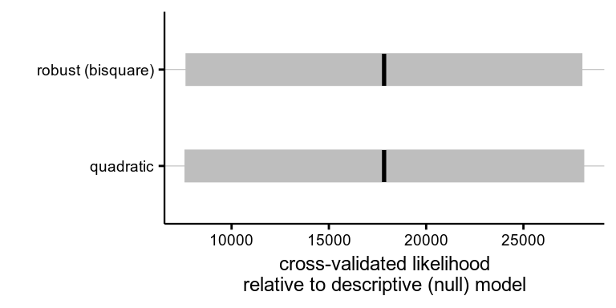

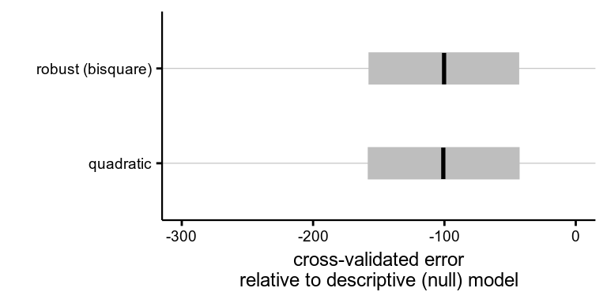

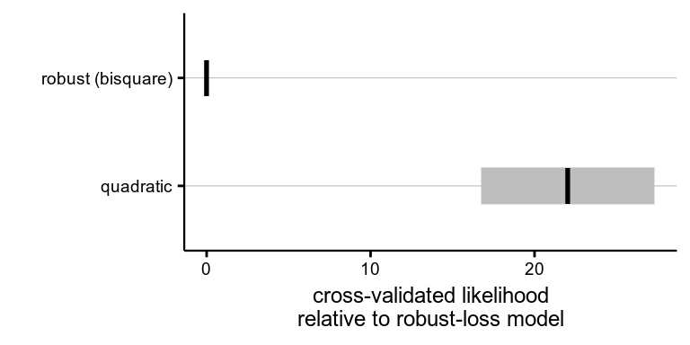

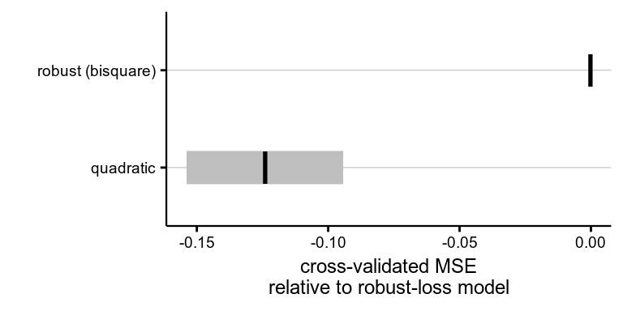

### Analysis of secondary saccades

```r
d2 <- read.table("./data/secondary_saccades_xp123_allfit.txt",sep="\t",header=T)

# # explo plot
# ggplot(d2, aes(x=rt,y=errorChange, color=factor(sacN_1)))+geom_hline(yintercept=0,size=0.2,lty=2)+nice_theme+labs(x="latency", y="change in position error")+geom_point(pch=21,size=1)+facet_grid(.~posu)

# cut offs
d2$corrective <- ifelse(d2$errorChange< 2.5 & d2$errorChange>-2.5, 1, 0)
d2 <- d2[d2$sacN_1==2,]

# ggplot(d2, aes(x=rt,y=errorChange, color=corrective))+geom_hline(yintercept=0,size=0.2,lty=2)+nice_theme+labs(x="latency", y="change in position error")+geom_point(pch=21,size=1)+facet_grid(.~posu)

d2 <- d2[d2$corrective==1,]
d2 <- d2[d2$rt>=30,]

# # plot overall latencies distributions
# dag <- aggregate(rt ~ posu + dir, d2, mean)
# ggplot(d2, aes(x=rt, fill=factor(posu)))+geom_histogram(binwidth=25,alpha=0.85)+geom_vline(data=dag, aes(xintercept=rt, color=factor(posu)))+nice_theme+labs(x="secondary saccade latency [ms]")+scale_fill_manual(values=c("black","dark grey", "blue"),name=expression(paste(sigma[blob]," [deg]")))+scale_color_manual(values=c("black","dark grey", "blue"),name=expression(paste(sigma[blob]," [deg]")))+facet_grid(dir~posu)

# given that there are relatively few observations, and that latency differences are generally noisy, I use the median which is more robust and less influenced by single extreme points (call them "outliers" if you want)
medianDiff <- function(dd) median(dd$res_RT[dd$dir=="opposite to primary"])-median(dd$res_RT[dd$dir=="same as primary"])
bootmedianDiffSE <- function(dd,nsim=1000){
  bootF <- function(dd,i) medianDiff(dd[i,])
  bootRes <- boot::boot(dd,bootF,nsim)
  return(sd(bootRes$t,na.rm=T))
}

# fit model at group level, including quadratic component
library(lme4)
m2all <- lmer(rt ~ ampli + I(ampli^2) + exp + exp:ampli + exp:I(ampli^2) + (ampli+I(ampli^2)|id), d2)

d2$res_RT <- residuals(m2all)

# pair values (alpha & sacc. pars.)
d2$id <- paste(d2$id, d2$exp,sep="_")
d_a <- aggregate(alpha ~ id + exp, dfit, mean)
d_a$alpha_se <- aggregate(alpha_se ~ id + exp, dfit, mean)$alpha_se
d_a$id <- paste(d_a$id, d_a$exp,sep="_")

d_a$RTdiff <- NA
d_a$RTdiff_se <- NA
d_a$errdiff <- NA
d_a$errChangediff <- NA

for(i in unique(d_a$id)){

  dd <- d2[d2$id==i,]

  d_a$RTdiff[d_a$id==i] <- medianDiff(dd)
  d_a$RTdiff_se[d_a$id==i] <- bootmedianDiffSE(dd,nsim=1000)
}

d_a$cost_ratio <- d_a$alpha / (1-d_a$alpha)
d_a$log_cost_ratio <- log(d_a$cost_ratio)

# measure correlation
mean(d_a$RTdiff)
```

```
## [1] 35.04204
```

```r
bootMeanCI(d_a$RTdiff)
```

```
## 2.690452%  97.6766%
##  19.49769  50.58442
```

```r
sum(d_a$RTdiff_se>60)
```

```
## [1] 4
```

```r
mean(d_a$RTdiff_se[d_a$RTdiff_se>60])
```

```
## [1] 89.6124
```

```r
mean(d_a$RTdiff_se[d_a$RTdiff_se<=60])
```

```
## [1] 24.48299
```

```r
with(d_a[d_a$RTdiff_se<60,], cor.test(log_cost_ratio, RTdiff))
```

```
##
##  Pearson's product-moment correlation
##
## data:  log_cost_ratio and RTdiff
## t = 3.7303, df = 53, p-value = 0.0004672
## alternative hypothesis: true correlation is not equal to 0
## 95 percent confidence interval:
##  0.2169672 0.6434665
## sample estimates:
##       cor
## 0.4560157
```

```r
with(d_a[d_a$RTdiff_se<60 & d_a$exp=="exp1",], cor.test(log_cost_ratio, RTdiff))
```

```
##
##  Pearson's product-moment correlation
##
## data:  log_cost_ratio and RTdiff
## t = 2.7407, df = 10, p-value = 0.02081
## alternative hypothesis: true correlation is not equal to 0
## 95 percent confidence interval:
##  0.1298471 0.8931381
## sample estimates:
##       cor
## 0.6549427
```

```r
with(d_a[d_a$RTdiff_se<60 & d_a$exp=="exp2",], cor.test(log_cost_ratio, RTdiff))
```

```
##
##  Pearson's product-moment correlation
##
## data:  log_cost_ratio and RTdiff
## t = 3.1247, df = 17, p-value = 0.00617
## alternative hypothesis: true correlation is not equal to 0
## 95 percent confidence interval:
##  0.2064074 0.8303921
## sample estimates:
##       cor
## 0.6039912
```

```r
with(d_a[d_a$RTdiff_se<60 & d_a$exp=="exp3",], cor.test(log_cost_ratio, RTdiff))
```

```
##
##  Pearson's product-moment correlation
##
## data:  log_cost_ratio and RTdiff
## t = 2.0155, df = 22, p-value = 0.05623
## alternative hypothesis: true correlation is not equal to 0
## 95 percent confidence interval:
##  -0.01023286  0.68853521
## sample estimates:
##       cor
## 0.3947935
```

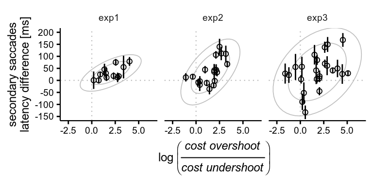

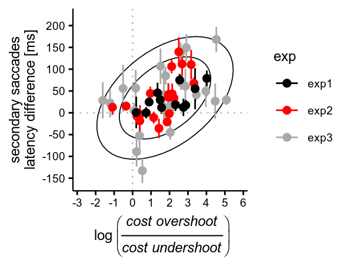